# TCC

# Modelos Binomial Negativa

```r
# modelo saturado
mod1_binneg <- glm.nb(frutos~bloco*trat, data = colheita)
summary(mod1_binneg) #AIC = 298.9
```

```
##
## Call:
## glm.nb(formula = frutos ~ bloco * trat, data = colheita, init.theta = 112356.5498,
##     link = log)
##
## Deviance Residuals:
##      Min        1Q    Median        3Q       Max
## -2.35932  -0.53640  -0.07488   0.56866   2.32544
##
## Coefficients:
##                Estimate Std. Error z value Pr(>|z|)
## (Intercept)   2.001e+00  1.644e-01  12.174   <2e-16 ***
## bloco2        8.419e-16  2.325e-01   0.000    1.000
## bloco3        1.011e-15  2.325e-01   0.000    1.000
## trat2        -2.740e-02  2.341e-01  -0.117    0.907
## trat4         7.796e-02  2.281e-01   0.342    0.733
## trat5        -3.151e-01  2.531e-01  -1.245    0.213
## bloco2:trat2 -1.823e-01  3.394e-01  -0.537    0.591
## bloco3:trat2 -3.254e-01  3.468e-01  -0.938    0.348
## bloco2:trat4 -1.625e-01  3.294e-01  -0.493    0.622
## bloco3:trat4 -1.335e-01  3.281e-01  -0.407    0.684
## bloco2:trat5  3.151e-01  3.437e-01   0.917    0.359
## bloco3:trat5  2.007e-01  3.484e-01   0.576    0.565
## ---
## Signif. codes:  0 '***' 0.001 '**' 0.01 '*' 0.05 '.' 0.1 ' ' 1
##
## (Dispersion parameter for Negative Binomial(112356.5) family taken to be 1)
##
##     Null deviance: 56.589  on 59  degrees of freedom
## Residual deviance: 50.295  on 48  degrees of freedom
## AIC: 298.9
##
## Number of Fisher Scoring iterations: 1
##
##
##               Theta:  112357
##           Std. Err.:  2425707
## Warning while fitting theta: iteration limit reached
##
##  2 x log-likelihood:  -272.899
```

```r
# modelo trat bloco
mod3_binneg <- glm.nb(frutos~trat+bloco, data = colheita)
summary(mod3_binneg) #AIC = 290.36
```

```
##
## Call:
## glm.nb(formula = frutos ~ trat + bloco, data = colheita, init.theta = 95262.80605,
##     link = log)
##
## Deviance Residuals:
##      Min        1Q    Median        3Q       Max
## -2.38719  -0.56431  -0.04155   0.49798   2.33300
##
## Coefficients:
##             Estimate Std. Error z value Pr(>|z|)
## (Intercept)  2.02802    0.11708  17.322   <2e-16 ***
## trat2       -0.18774    0.14100  -1.332    0.183
## trat4       -0.01818    0.13485  -0.135    0.893
## trat5       -0.13482    0.13900  -0.970    0.332
## bloco2      -0.01439    0.11996  -0.120    0.905
## bloco3      -0.06645    0.12156  -0.547    0.585
## ---
## Signif. codes:  0 '***' 0.001 '**' 0.01 '*' 0.05 '.' 0.1 ' ' 1
##
## (Dispersion parameter for Negative Binomial(95262.81) family taken to be 1)
##
##     Null deviance: 56.589  on 59  degrees of freedom
## Residual deviance: 53.757  on 54  degrees of freedom
## AIC: 290.36
##
## Number of Fisher Scoring iterations: 1
##
##
##               Theta:  95263
##           Std. Err.:  2286198
## Warning while fitting theta: iteration limit reached
##
##  2 x log-likelihood:  -276.361
```

```r
# modelo trat
mod5_binneg <- glm.nb(frutos~trat, data = colheita)
summary(mod5_binneg) #AIC = 286.69
```

```
##
## Call:
## glm.nb(formula = frutos ~ trat, data = colheita, init.theta = 95417.57242,
##     link = log)
##
## Deviance Residuals:
##      Min        1Q    Median        3Q       Max
## -2.35931  -0.54944  -0.05403   0.57180   2.21227
##
## Coefficients:
##             Estimate Std. Error z value Pr(>|z|)
## (Intercept)  2.00148    0.09492  21.086   <2e-16 ***
## trat2       -0.18774    0.14100  -1.332    0.183
## trat4       -0.01818    0.13485  -0.135    0.893
## trat5       -0.13482    0.13900  -0.970    0.332
## ---
## Signif. codes:  0 '***' 0.001 '**' 0.01 '*' 0.05 '.' 0.1 ' ' 1
##
## (Dispersion parameter for Negative Binomial(95417.57) family taken to be 1)
##
##     Null deviance: 56.589  on 59  degrees of freedom
## Residual deviance: 54.087  on 56  degrees of freedom
## AIC: 286.69
##
## Number of Fisher Scoring iterations: 1
##
##
##               Theta:  95418
##           Std. Err.:  2339369
## Warning while fitting theta: iteration limit reached
##
##  2 x log-likelihood:  -276.691
```

```r
# modelo bloco
mod6_binneg <- glm.nb(frutos~bloco, data = colheita)
summary(mod6_binneg) #AIC = 286.86
```

```
##
## Call:
## glm.nb(formula = frutos ~ bloco, data = colheita, init.theta = 73574.0309,
##     link = log)
##
## Deviance Residuals:
##     Min       1Q   Median       3Q      Max
## -2.2014  -0.6644   0.0000   0.3694   2.5235
##
## Coefficients:
##             Estimate Std. Error z value Pr(>|z|)
## (Intercept)  1.94591    0.08452  23.023   <2e-16 ***
## bloco2      -0.01439    0.11996  -0.120    0.905
## bloco3      -0.06645    0.12156  -0.547    0.585
## ---
## Signif. codes:  0 '***' 0.001 '**' 0.01 '*' 0.05 '.' 0.1 ' ' 1
##
## (Dispersion parameter for Negative Binomial(73574.03) family taken to be 1)
##
##     Null deviance: 56.588  on 59  degrees of freedom
## Residual deviance: 56.258  on 57  degrees of freedom
## AIC: 286.86
##
## Number of Fisher Scoring iterations: 1
##
##
##               Theta:  73574
##           Std. Err.:  1911434
## Warning while fitting theta: iteration limit reached
##
##  2 x log-likelihood:  -278.863
```

```r
# modelo vazio
mod8_binneg <- glm.nb(frutos~1, data = colheita)
summary(mod8_binneg) #AIC = 283.19
```

```
##
## Call:
## glm.nb(formula = frutos ~ 1, data = colheita, init.theta = 72901.08803,
##     link = log)
##
## Deviance Residuals:
##     Min       1Q   Median       3Q      Max
## -2.1744  -0.7307   0.0699   0.4410   2.4050
##
## Coefficients:
##             Estimate Std. Error z value Pr(>|z|)
## (Intercept)  1.91937    0.04945   38.81   <2e-16 ***
## ---
## Signif. codes:  0 '***' 0.001 '**' 0.01 '*' 0.05 '.' 0.1 ' ' 1
##
## (Dispersion parameter for Negative Binomial(72901.09) family taken to be 1)
##
##     Null deviance: 56.588  on 59  degrees of freedom
## Residual deviance: 56.588  on 59  degrees of freedom
## AIC: 283.19
##
## Number of Fisher Scoring iterations: 1
##
##
##               Theta:  72901
##           Std. Err.:  1954015
## Warning while fitting theta: iteration limit reached
##
##  2 x log-likelihood:  -279.193
```

Vale ressaltar que em todos os modelos, nenhum fator foi significativo. Portanto, o melhor modelo não tem nenhuma variável explicativa.

Melhor modelo (Poisson - vazio):

$log(\mu_i) = 1.91937$

```r
summary(mod5)
```

```
##
## Call:
## glm(formula = frutos ~ 1, family = poisson, data = colheita)
##
## Deviance Residuals:
##      Min        1Q    Median        3Q       Max
## -2.17450  -0.73076   0.06991   0.44099   2.40511
##
## Coefficients:
##             Estimate Std. Error z value Pr(>|z|)
## (Intercept)  1.91937    0.04945   38.82   <2e-16 ***
## ---
## Signif. codes:  0 '***' 0.001 '**' 0.01 '*' 0.05 '.' 0.1 ' ' 1
##
## (Dispersion parameter for poisson family taken to be 1)
##
##     Null deviance: 56.593  on 59  degrees of freedom
## Residual deviance: 56.593  on 59  degrees of freedom
## AIC: 281.19
##
## Number of Fisher Scoring iterations: 4
```

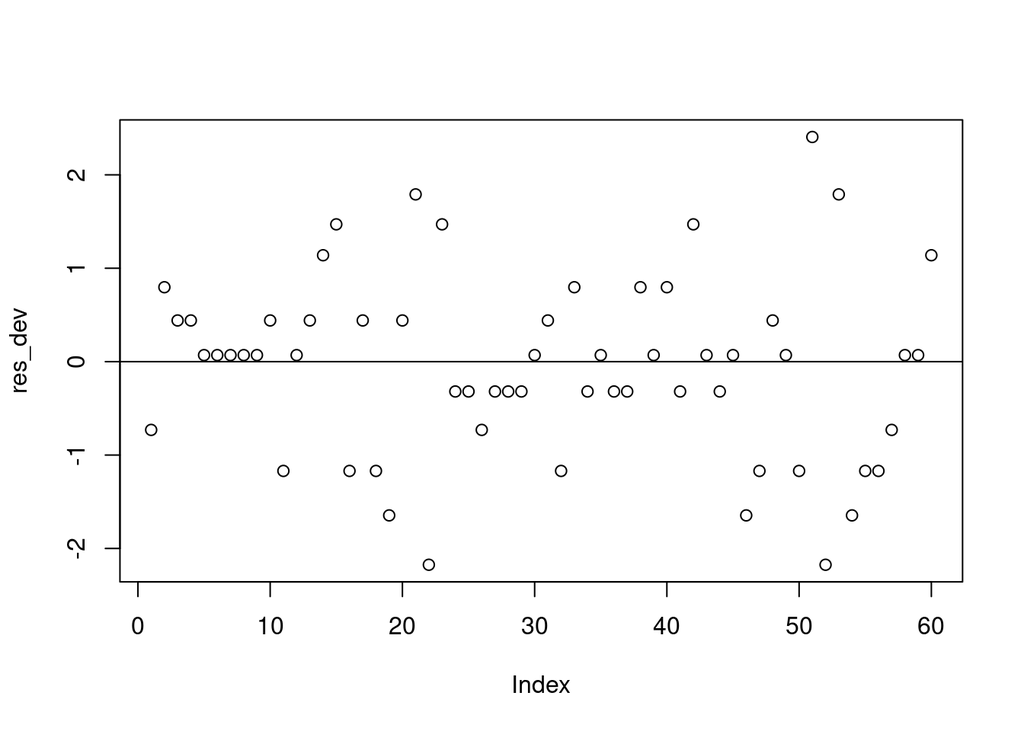

```
## integer(0)
```

```r
deviance <- deviance(mod5)

res_dev <- resid(mod5,type="deviance")
plot(res_dev)+abline(0,0)
```

```r
shapiro.test(res_dev)
```

```
##
##  Shapiro-Wilk normality test
##
## data:  res_dev
## W = 0.9726, p-value = 0.1952
```

```r
1-pchisq(deviance,59)
```

```
## [1] 0.564761
```

O resíduos deviance para este modelo é 56,59. Pelo teste Qui-quadrado de razão de verossimilhança, o modelo está adequado (p-valor 0.564761 com 59 graus de liberdade).

Gráfico dos valores preditos vs resíduos (todos os valores preditos são iguais, mas dei uma chocalhada para mehorar a visualização.)

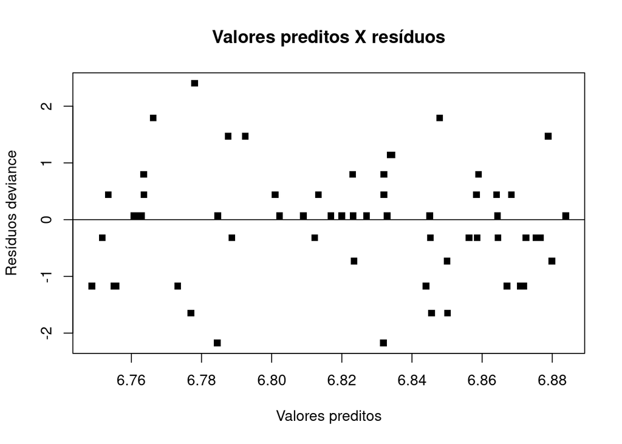

```r
plot(res_dev ~ jitter(mod5$fitted.values, 0.5), pch = 15,main="Valores preditos X resíduos",xlab="Valores preditos",ylab="Resíduos deviance")
abline(0,0)
```

Gráfico envelope:

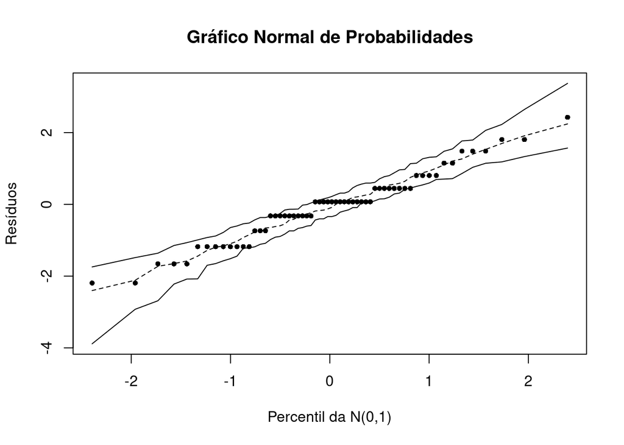

```r
envelope=function(modelo){
  dados=na.omit(modelo$data)
  nsim=100
  n=modelo$df.null+1
  r1=sort(rstandard(modelo,type='deviance'))
  m1=matrix(0,nrow=n,ncol=nsim)
  a2=simulate(modelo,nsim=nsim)

  for (i in 1:nsim){
    dados$y=a2[,i]
    aj=update(modelo,y~.,data=dados)
    m1[,i]=sort(rstandard(aj,type='deviance'))}

  li=apply(m1,1,quantile,0.025)
  m=apply(m1,1,quantile,0.5)
  ls=apply(m1,1,quantile,0.975)

  quantis=qnorm((1:n-0.5)/n)

  plot(rep(quantis,2),c(li,ls),type='n',xlab='Percentil da N(0,1)',ylab='Resíduos')
  title('Gráfico Normal de Probabilidades')
  lines(quantis,li,type='l')
  lines(quantis,m,type='l',lty=2)
  lines(quantis,ls,type='l')
  points(quantis,r1,pch=16,cex=0.75)
}
envelope(mod5)
```